# Chap3

Paloma

11/28/2019

# Chapter 3

## 3.1 Intro

## 3.2 First steps

The idea is that we have: `ggplot(data) + <GEOM_FUNCTION(aes(), other feat>`

```r
str(mpg)
```

```
## Classes 'tbl_df', 'tbl' and 'data.frame':    234 obs. of  11 variables:
##  $ manufacturer: chr  "audi" "audi" "audi" "audi" ...
##  $ model       : chr  "a4" "a4" "a4" "a4" ...
##  $ displ       : num  1.8 1.8 2 2 2.8 2.8 3.1 1.8 1.8 2 ...
##  $ year        : int  1999 1999 2008 2008 1999 1999 2008 1999 1999 2008 ...
##  $ cyl         : int  4 4 4 4 6 6 6 4 4 4 ...
##  $ trans       : chr  "auto(l5)" "manual(m5)" "manual(m6)" "auto(av)" ...
##  $ drv         : chr  "f" "f" "f" "f" ...
##  $ cty         : int  18 21 20 21 16 18 18 18 16 20 ...
##  $ hwy         : int  29 29 31 30 26 26 27 26 25 28 ...
##  $ fl          : chr  "p" "p" "p" "p" ...
##  $ class       : chr  "compact" "compact" "compact" "compact" ...
```

```r
dim(mpg)
```

```
## [1] 234  11
```

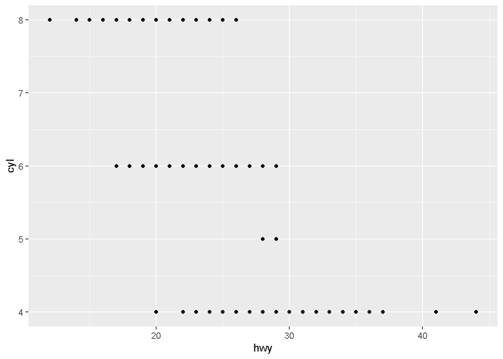

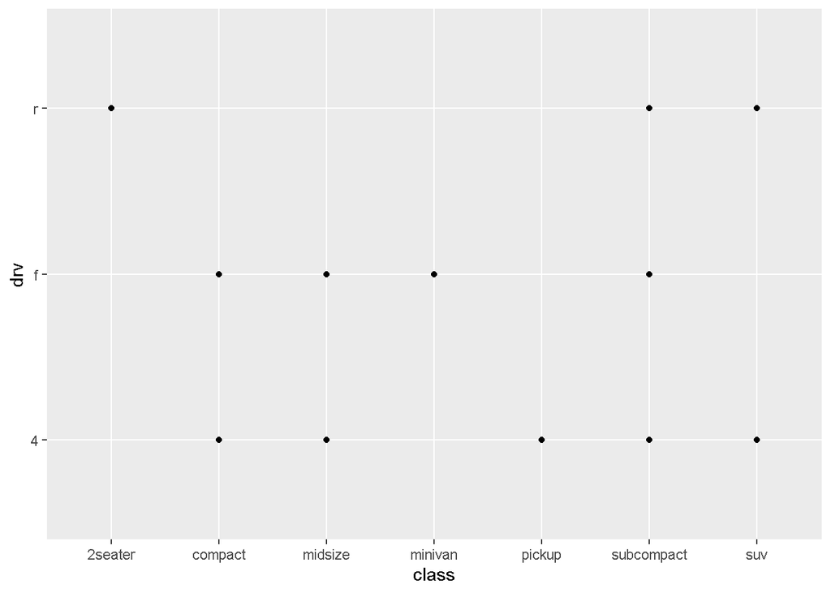

```r
ggplot(data = mpg,
       aes(hwy, cyl)) +
  geom_point()

ggplot(data = mpg,
       aes(class, drv)) +
  geom_point()
```

We cant see the distribution of observations across categories.

## 3.3 Aesthetic mapping

Key tip: `group`: does not give a legend

`size`: not advised for discrete categories, ideally for weights or a count variable

`fill`: can also give color to some geom, but not `geom_plot`. I think it is similar to the shape/color and fill relationship.

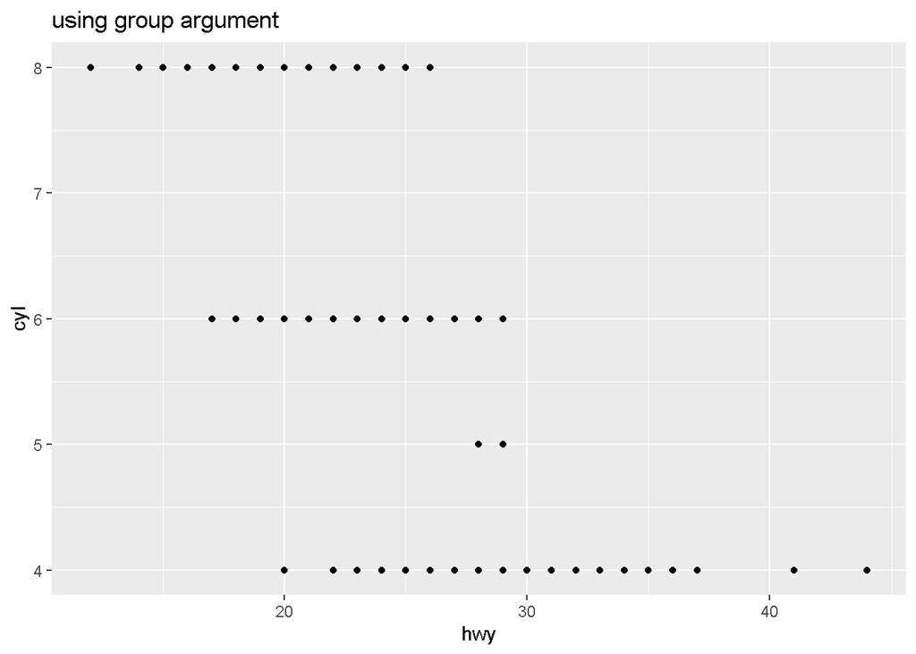

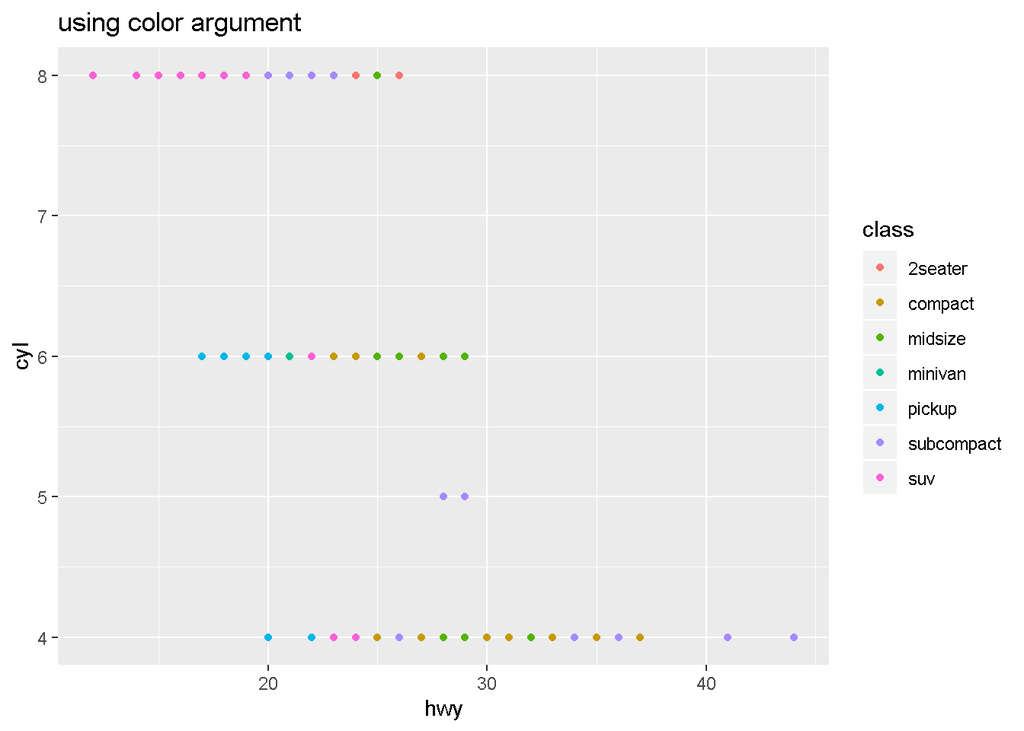

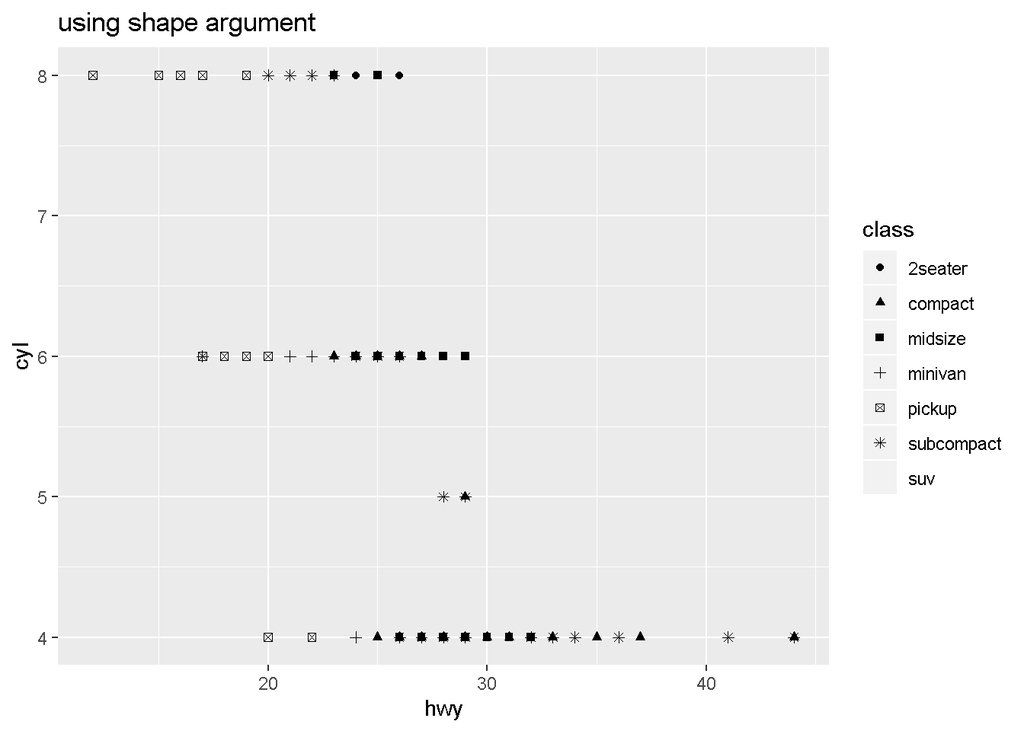

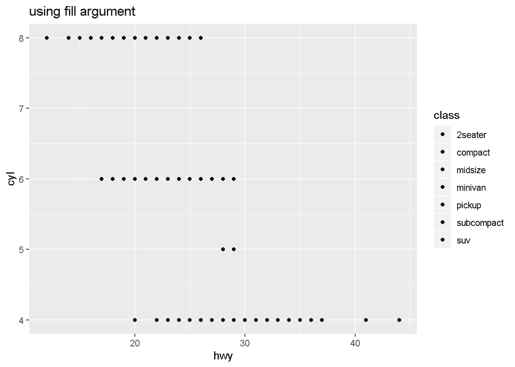

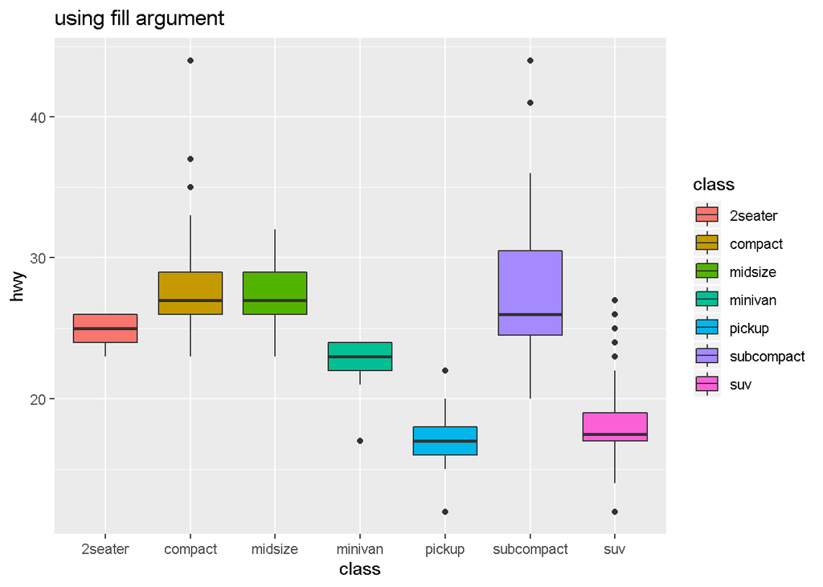

```r
ggplot(data = mpg,
       aes(hwy, cyl, group = class)) +
  geom_point() +
  labs(title = "using group argument")

ggplot(data = mpg,
       aes(hwy, cyl, color = class)) +
  geom_point() +
    labs(title = "using color argument")

ggplot(data = mpg,
       aes(hwy, cyl, shape = class)) +
  geom_point() +
    labs(title = "using shape argument")
ggplot(data = mpg,
       aes(hwy, cyl, fill = class)) +
  geom_point() +
    labs(title = "using fill argument")

ggplot(data = mpg,
       aes(class, hwy)) +
  geom_boxplot(aes(fill = class)) +
    labs(title = "using fill argument")
```

If we want only one shape or color, that would NOT have to be inside the `aes()`, but as an argument of the `<geom_function()>`

About the `shape`, it goes with `color` and `fill`.

- From 0 to 14 *borders* are determined by `color`
- From 15 to 18 are *filled* by `color`
- From 21 - 24 the *border* is defined by `color` and *filled* with `fill`

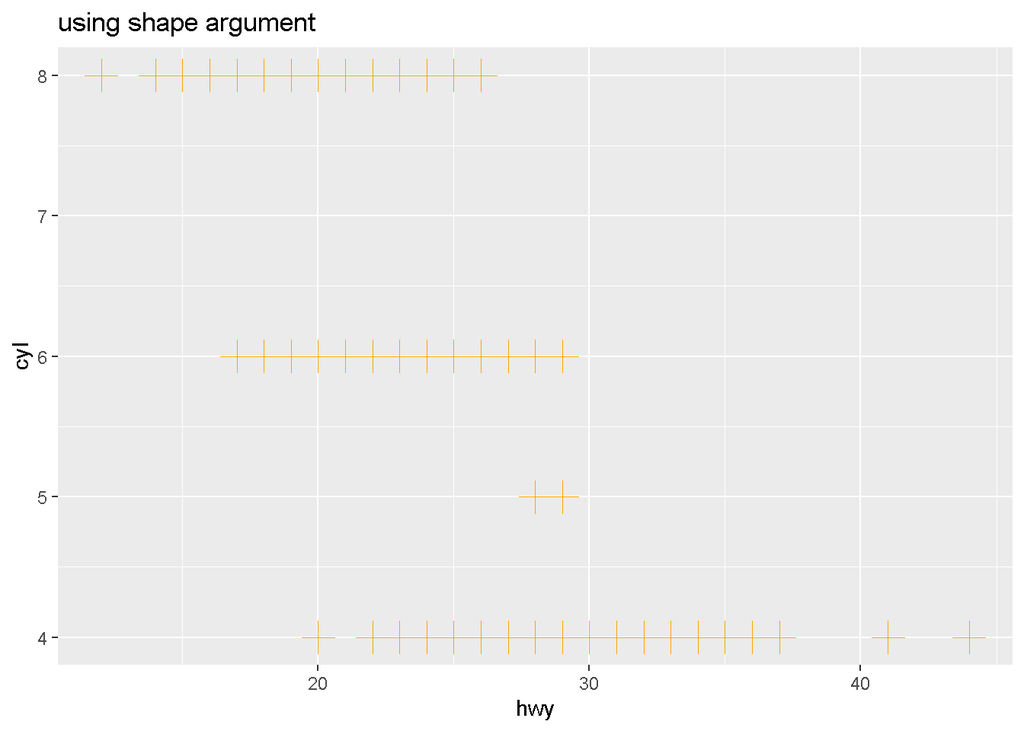

```r
ggplot(data = mpg, aes(hwy, cyl)) +
  geom_point(shape = 3, color = "orange", size = 5) +
    labs(title = "using shape argument")
```

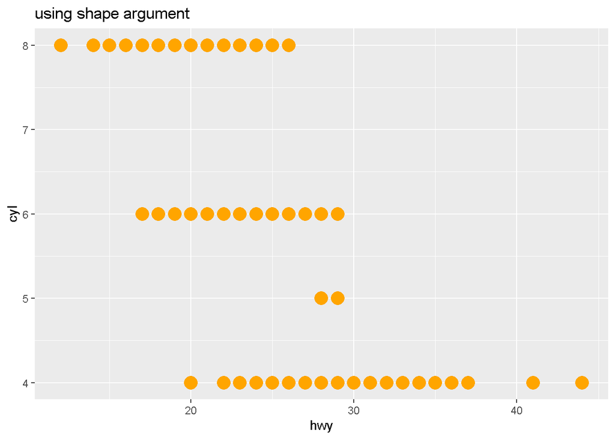

```r
ggplot(data = mpg, aes(hwy, cyl)) +
  geom_point(shape = 16, color = "orange", size = 5) +
    labs(title = "using shape argument")
```

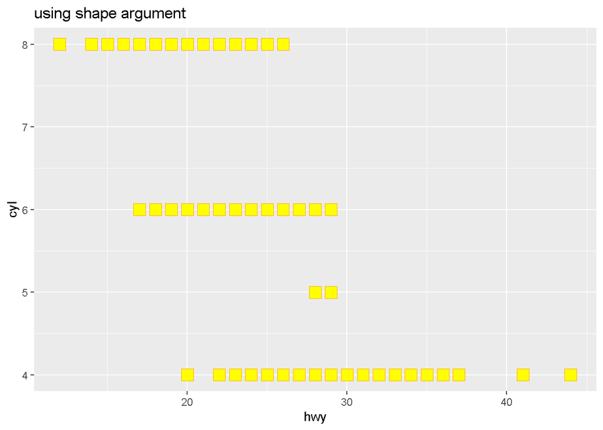

```r
ggplot(data = mpg, aes(hwy, cyl)) +
  geom_point(shape = 22, color = "orange", fill = "yellow", size = 5) +
    labs(title = "using shape argument")
```

## 3.4 Common problems

Just remeber to use `?function_name`.

## 3.5 Facets

`facet_wrap` = makes rows, and usually goes like `facet_wrap(~ cat_var)`

We can add `nrow` and `ncol`, `strip.position` (which is the version for `switch`) changes where the title of each category goes, could be “right”, “left”, “bottom”, etc..

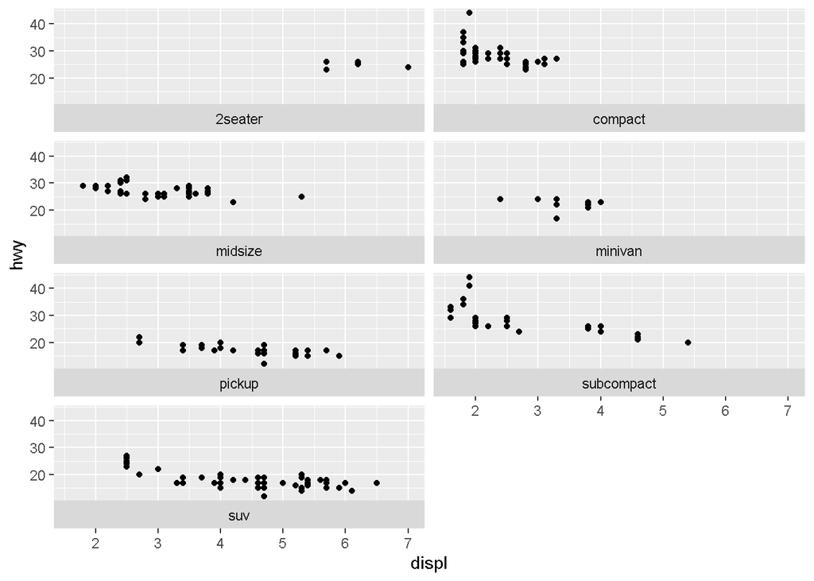

```r
ggplot(data = mpg) +
  geom_point(mapping = aes(x = displ, y = hwy)) +
  facet_wrap(~ class, nrow = 4, ncol = 2, strip.position = "bottom")
```

- `facet_grid` = Makes columns, it usually goes like `facet_grid(.~ cat_var)`

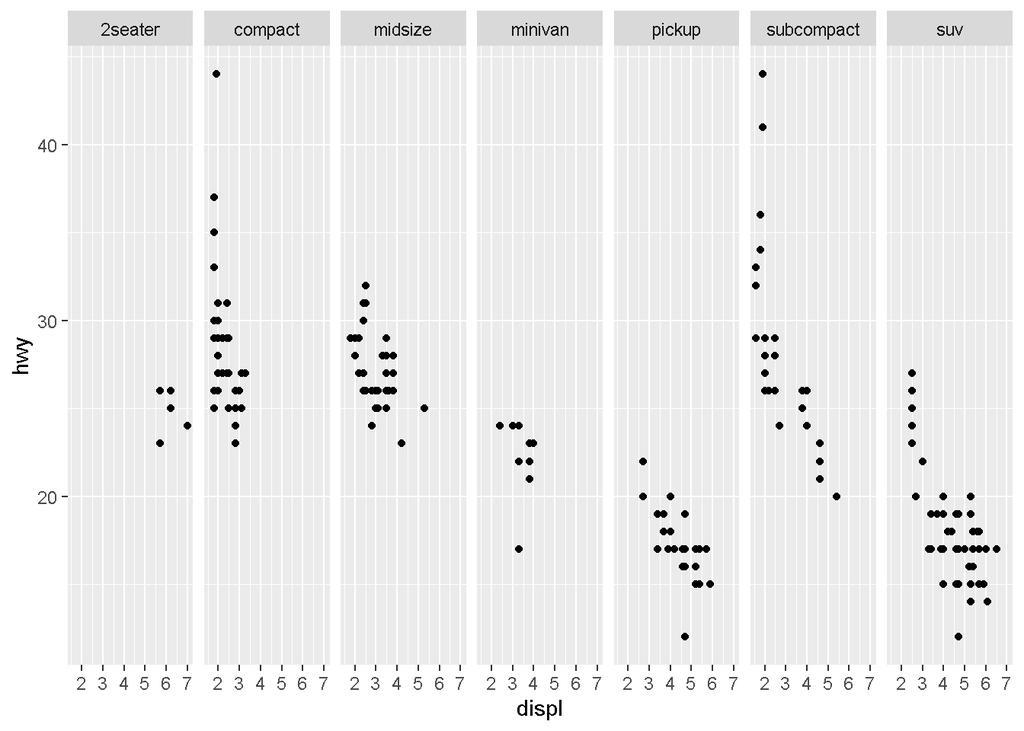

```r
ggplot(data = mpg) +
  geom_point(mapping = aes(x = displ, y = hwy)) +
  facet_grid(. ~ class)
```

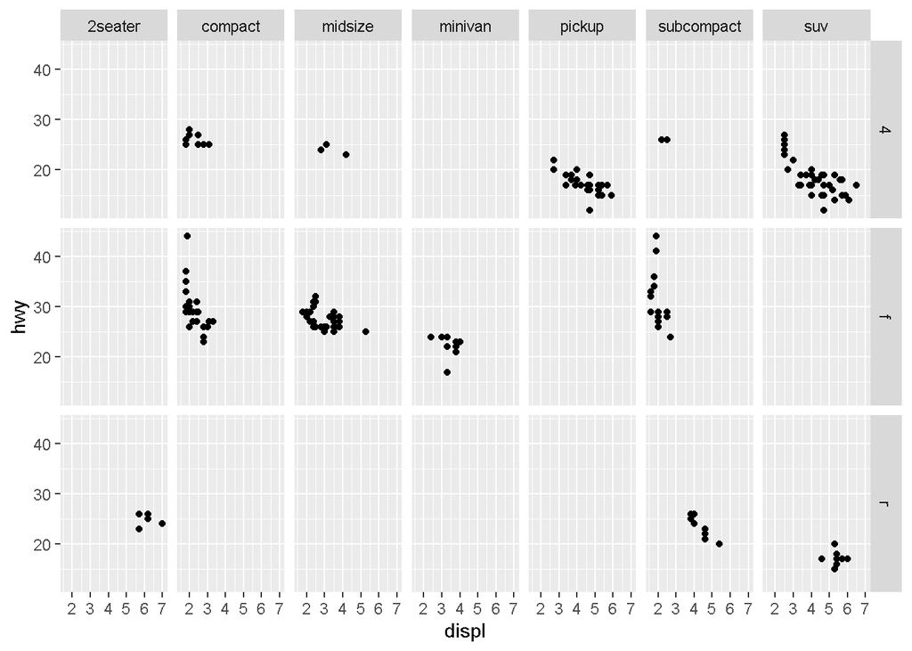

```r
ggplot(data = mpg) +
  geom_point(mapping = aes(x = displ, y = hwy)) +
  facet_grid(drv ~ class)
```

## 3.6 Geometric objects

The key concept is that not every geom has the same aesthetics.

For example `geom_smooth` has the “linetype” argument that shows a different line for each `cat_var`.

If I had used the `group` instead of color, I would have had three lines from the same color, and no legend.

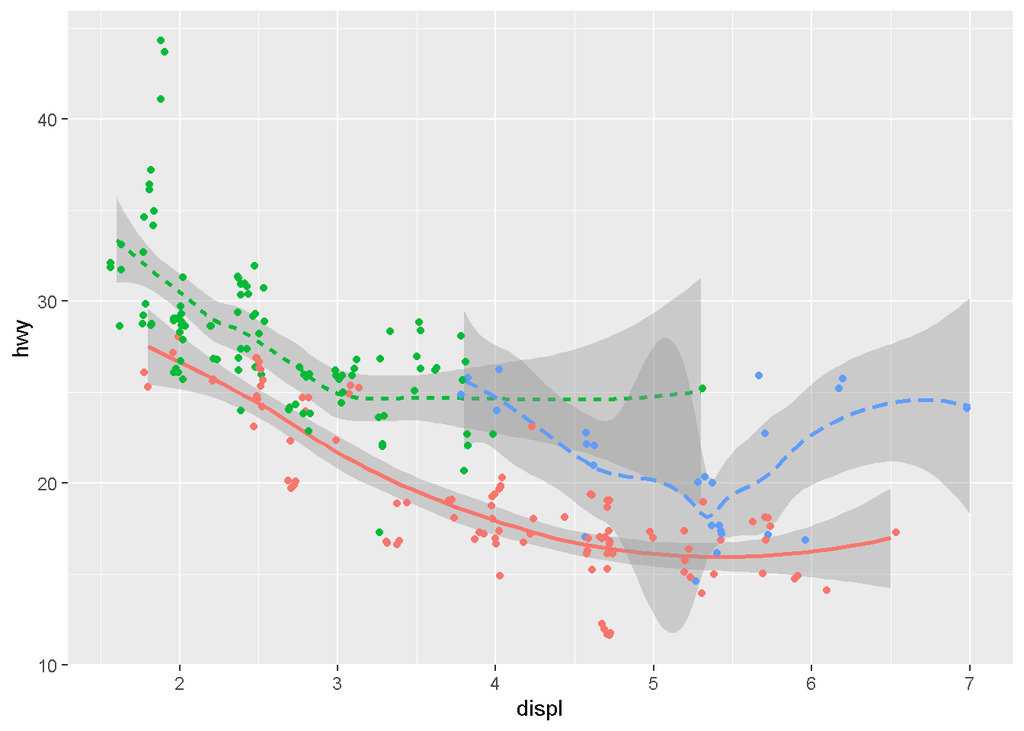

```r
mpg %>%
  ggplot(aes(x = displ, y = hwy, color = drv)) +
  geom_smooth(aes(linetype = drv), show.legend = FALSE) +
  geom_point(show.legend = FALSE, position = "jitter")
```

The idea is that for each geom, the aes apply to each layer.

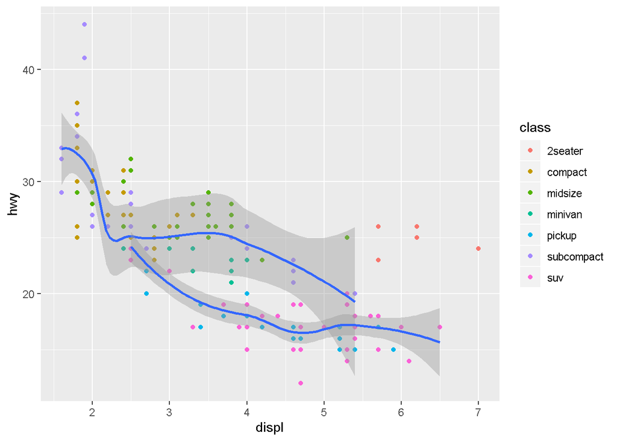

```r
mpg %>%
  ggplot(aes(x = displ, y = hwy)) +
  geom_point(mapping = aes(color = class), show.legend = TRUE) +
  geom_smooth(data = filter(mpg, class == "subcompact"), se = TRUE) +
  geom_smooth(data = filter(mpg, class == "suv"), se = TRUE)
```

A line chart?

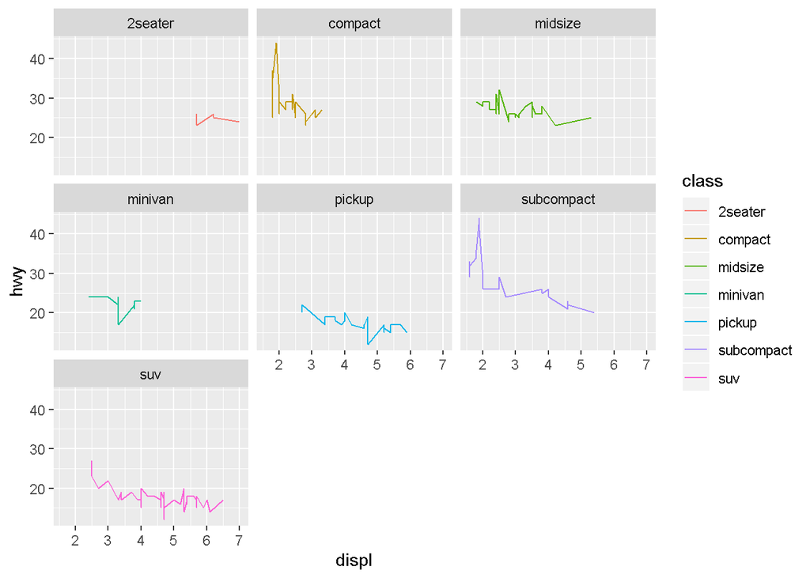

```r
mpg %>%
  ggplot(aes(x = displ, y = hwy, color =  class)) +
  geom_line() +
  facet_wrap(. ~ class)
```

Some graphs

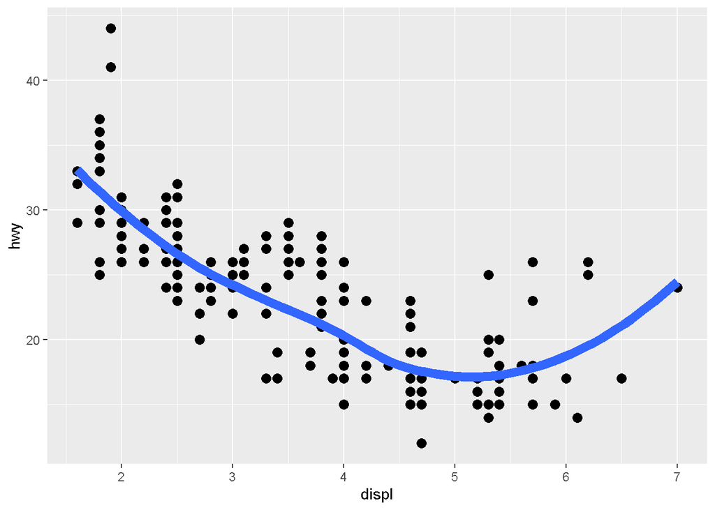

```r
mpg %>%
  ggplot(aes(displ, hwy)) +
  geom_point(size = 3) +
  geom_smooth(se = FALSE, size = 3)
```

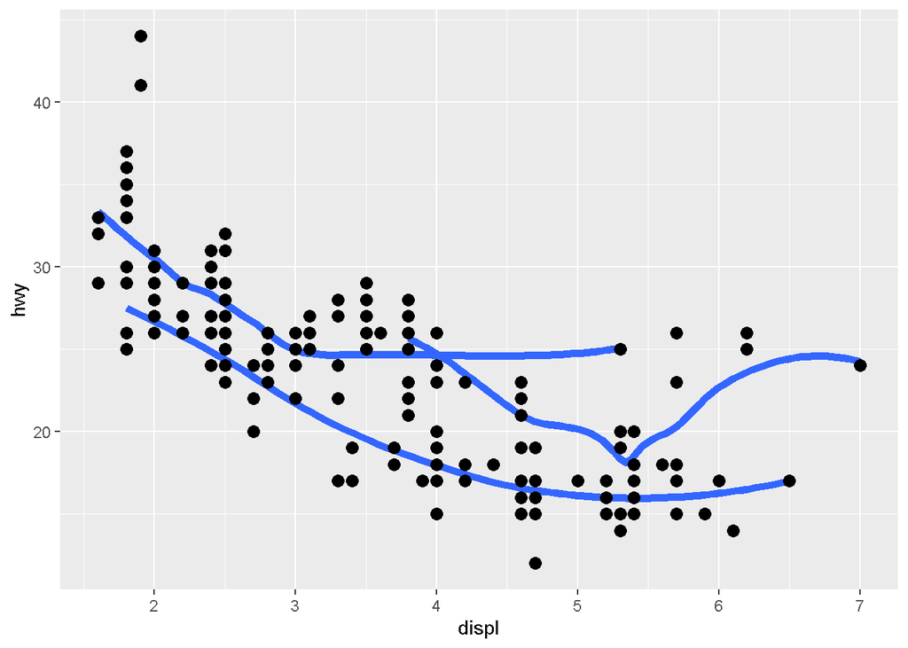

```r
mpg %>%
  ggplot(aes(displ, hwy)) +
  geom_smooth(aes(group =  drv), se = FALSE, size = 2 ) +
  geom_point(size = 3)
```

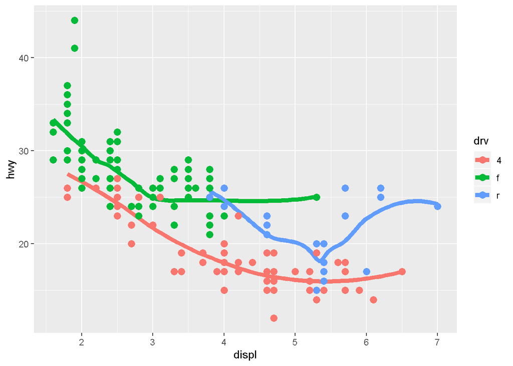

```r
mpg %>%
  ggplot(aes(displ, hwy, color = drv)) +
  geom_smooth(se = FALSE, size = 2 ) +
  geom_point(size = 3)
```

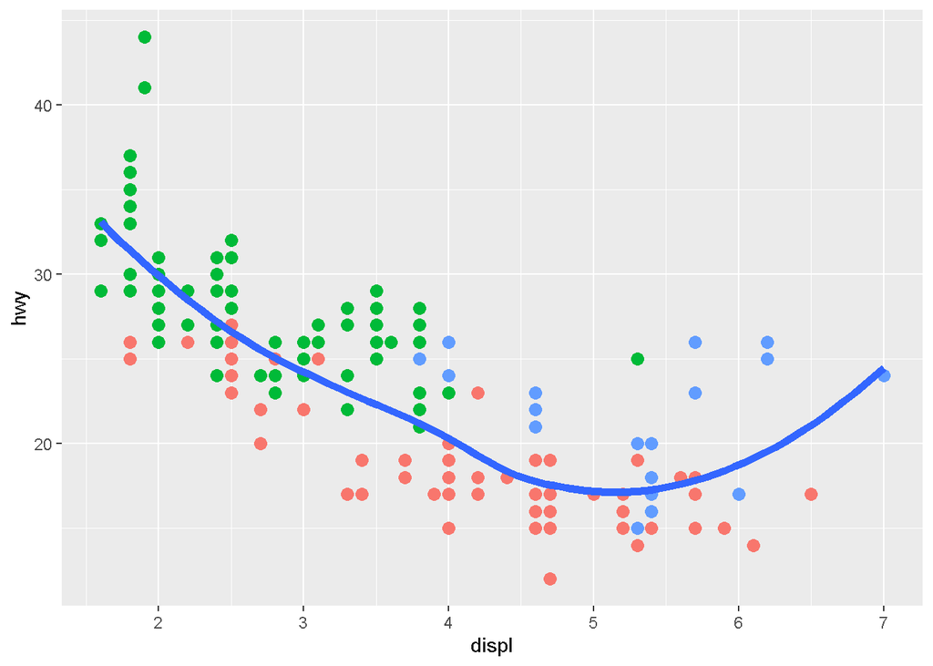

```r
mpg %>%
  ggplot(aes(displ, hwy)) +
  geom_point(aes(color = drv),size = 3, show.legend = FALSE) +
  geom_smooth(se = FALSE, size = 2 )
```

## 3.7 Statistical transformations

Geom_bar and stat_count are very similar. By default `geom_bar` has as an argument `stat = "count"`, that if we change by “identity”, is going to look different.

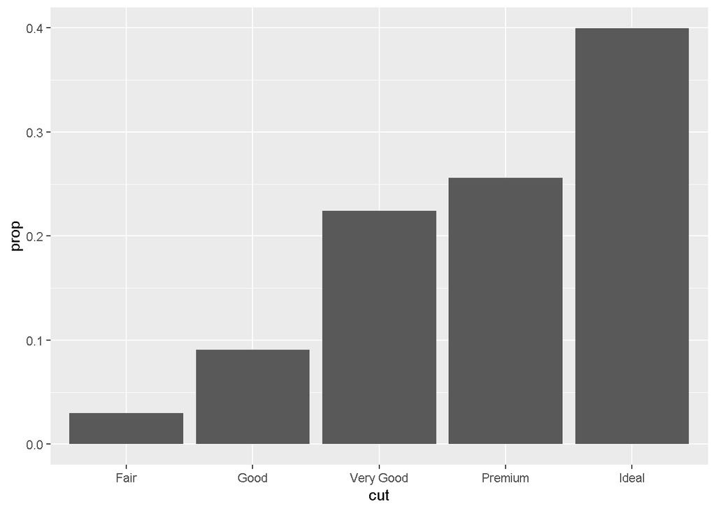

```r
diamonds %>%
  ggplot(aes(x = cut)) +
  geom_bar(aes(y = ..prop.., group = 1), show.legend = FALSE)
```

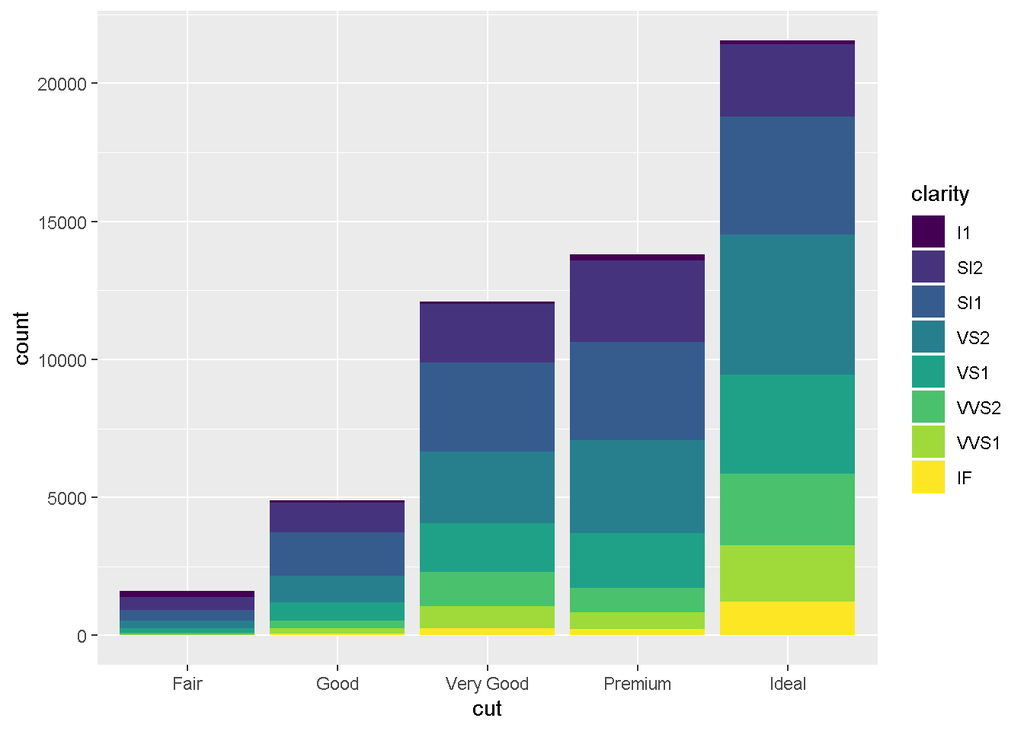

```r
diamonds %>%
  ggplot(aes(x = cut, fill = clarity)) +
  geom_bar()
```

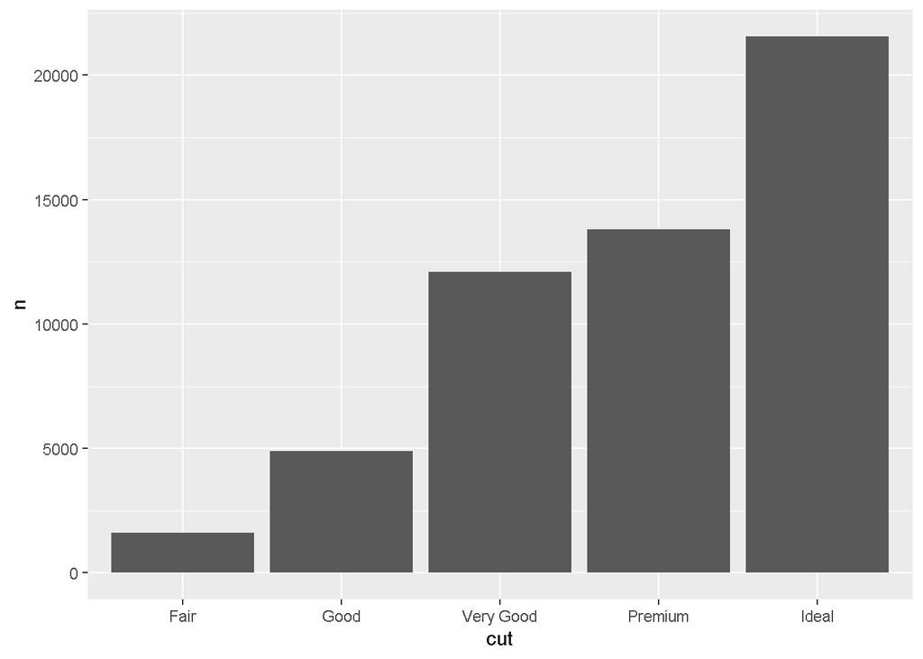

```r
diamonds %>%
  count(cut) %>%
  ggplot(aes(x = cut, y  = n)) +
  geom_bar(stat = "identity")
```

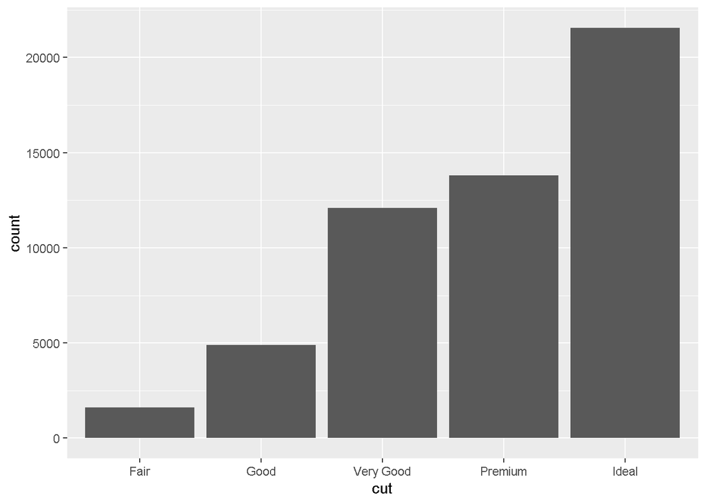

```r
diamonds %>%
  ggplot(aes(x = cut)) +
  stat_count()
```

Now `stat_summary` could save me lots of trouble

Please notice that stat_summary has `show.legend`

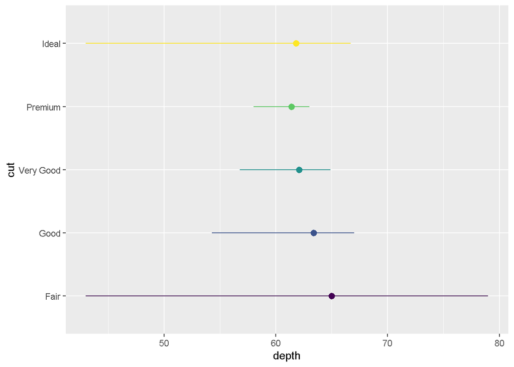

```r
diamonds %>%
  ggplot() +
  stat_summary(
    aes(x = cut, y = depth, color = cut),
    fun.y = median,
    fun.ymax = max,
    fun.ymin = min,
    show.legend = FALSE) +
  coord_flip()
```

`fun.data` crea un df con la media y ds Otra para revisar que esta buena es esta para lineranges, que seria trazar lineas y puntos con la min y max, se, etc. https://ggplot2.tidyverse.org/reference/geom_linerange.html

## 3.8 Position adjustments

In barcharts, if we use in the `fill` (or `color`) argument a different `cat_var`, we get a “stacked” look.

We can change this with the argument `position` that use 3 options: “identity”, “dodge”, “fill”.

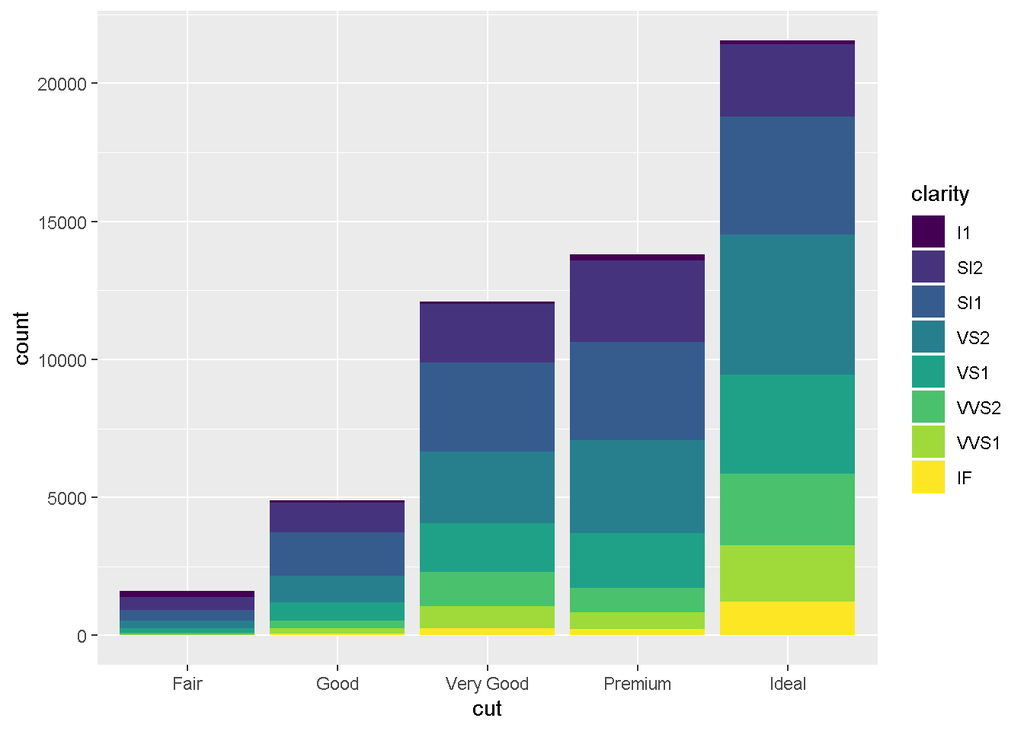

```r
diamonds %>%
  ggplot(aes(x = cut, fill = clarity)) +
  geom_bar()
```

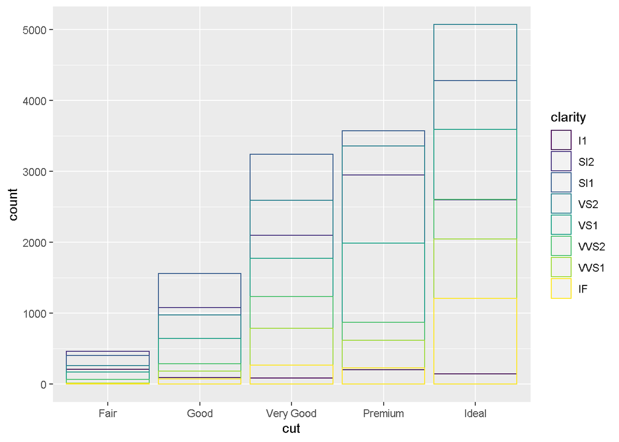

```r
diamonds %>%
  ggplot(aes(x = cut, color = clarity)) +
  geom_bar(fill = NA, position = "identity")
```

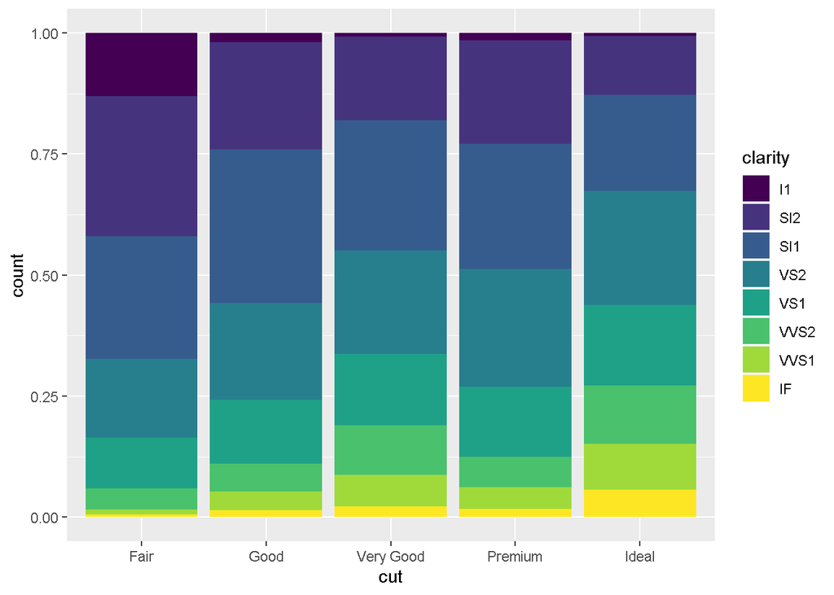

```r
diamonds %>%
  ggplot(aes(x = cut, fill = clarity)) +
  geom_bar(position = "fill")
```